# IODS course project

# Chapter 3: Logistic Regression

*Performing logistic regression analysis on the student alcohol consumption data*

- We’ll use the data wrangled in the first part of exercise 3: the full description of the data can be found [here](https://archive.ics.uci.edu/ml/datasets/STUDENT+ALCOHOL+CONSUMPTION)
- The data is collected on mathematics and portuguese classes: only students who answered the questionnaire on both classes have been included in the analyses.

It includes the following variables:

```r
# load visualization libraries

library(dplyr)
```

```r
library(ggplot2)
# read the data
alc <- read.table("./data/alc_students.txt",header = T,  dec = ".")


print(colnames(alc))
```

```
##  [1] "school"     "sex"        "age"        "address"    "famsize"
##  [6] "Pstatus"    "Medu"       "Fedu"       "Mjob"       "Fjob"
## [11] "reason"     "nursery"    "internet"   "guardian"   "traveltime"
## [16] "studytime"  "failures"   "schoolsup"  "famsup"     "paid"
## [21] "activities" "higher"     "romantic"   "famrel"     "freetime"
## [26] "goout"      "Dalc"       "Walc"       "health"     "absences"
## [31] "G1"         "G2"         "G3"         "alc_use"    "high_use"
```

The student alcohol consumption during weekdays has been recorded in the variable Dalc, and that during weekends in Walc. The average of the two is stored in the variable alc_use. Based on this value, the stuents have been dividen in two groups: those with high alcohol use (average over 2), and the others: this is indicated in the boolean variable high_use.

Next we will try to explain the high alcohol use with other variables. Now, it is not clear if he other variables cause high alcohol use, or vice versa. Still, in our model, we will explain the alcohol use using the other variables, disregarding any direction of (possible) causality.

Variables that might be related to high alcohol consumption include the student’s sex, (variable sex), quality of family relationships (famrel), being in a romantic relationship (romantic), and number of school absences (absences). I would guess that, on average, males have a higher risk of high alcohol consumption. Number of school absences would possibly increase the likelihood of high alcohol use, while being in a romantic relationship and good family relationships would decrease the likelihood. Next, well explore whether these hypotheses hold true or not.

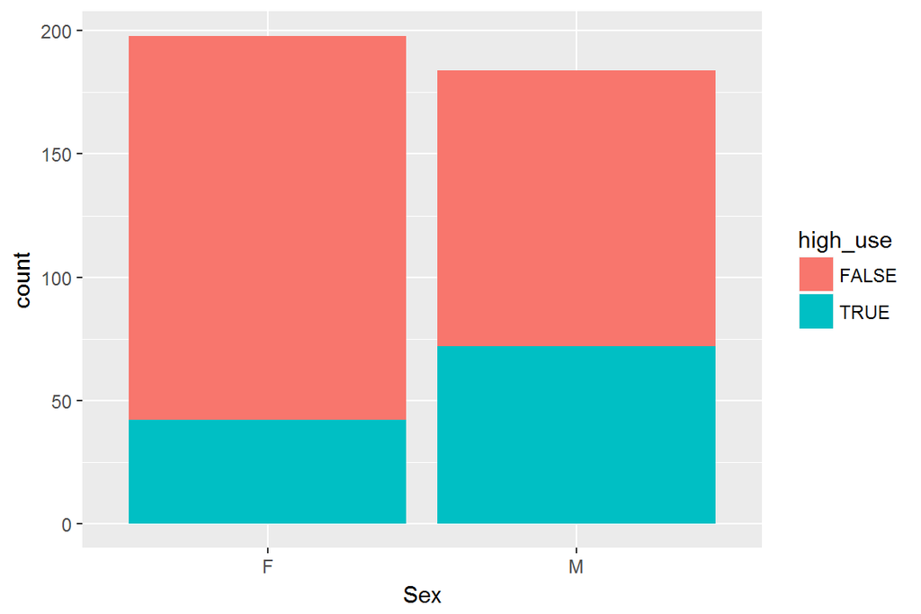

```r
# initialize a plot of alcohol use
g1 <- ggplot(data = alc, aes(x = sex, fill = high_use))

# define the plot as a bar plot and draw it
g1 + geom_bar() + xlab("Sex")
```

In the figure we can see that, first of all, there are a few more females compared to males. However, there are almost twice as many high alcohol users within males: so this would seem to support the initial hypothesis. We will test this further with a logistic regression model in a moment. Before that, let’s look at the other variables.

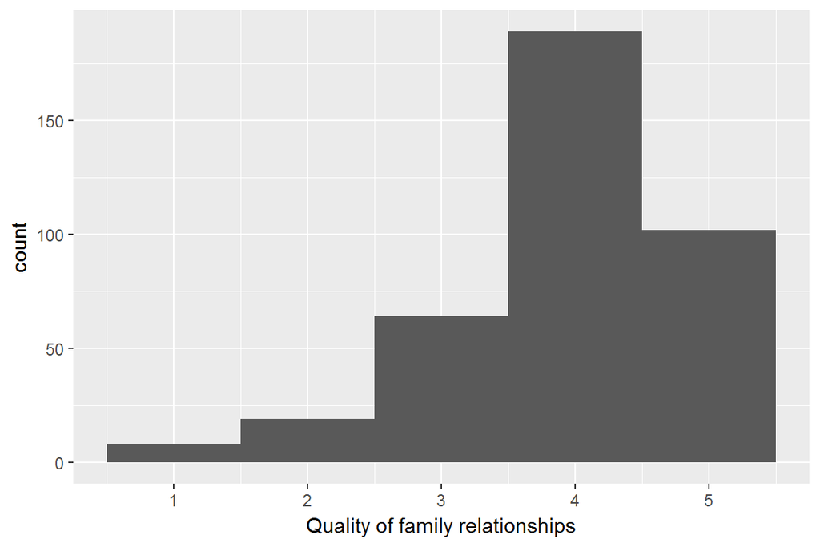

```r
# initialize a plot of alcohol use
g2 <- ggplot(data = alc, aes(x = famrel))

# define the plot as a bar plot and draw it
g2 + geom_histogram(binwidth = 1) + xlab("Quality of family relationships")
```

We can see that most of the respondents have relatively good family relations. Now, let’s check how these affect the alcohol consumption:

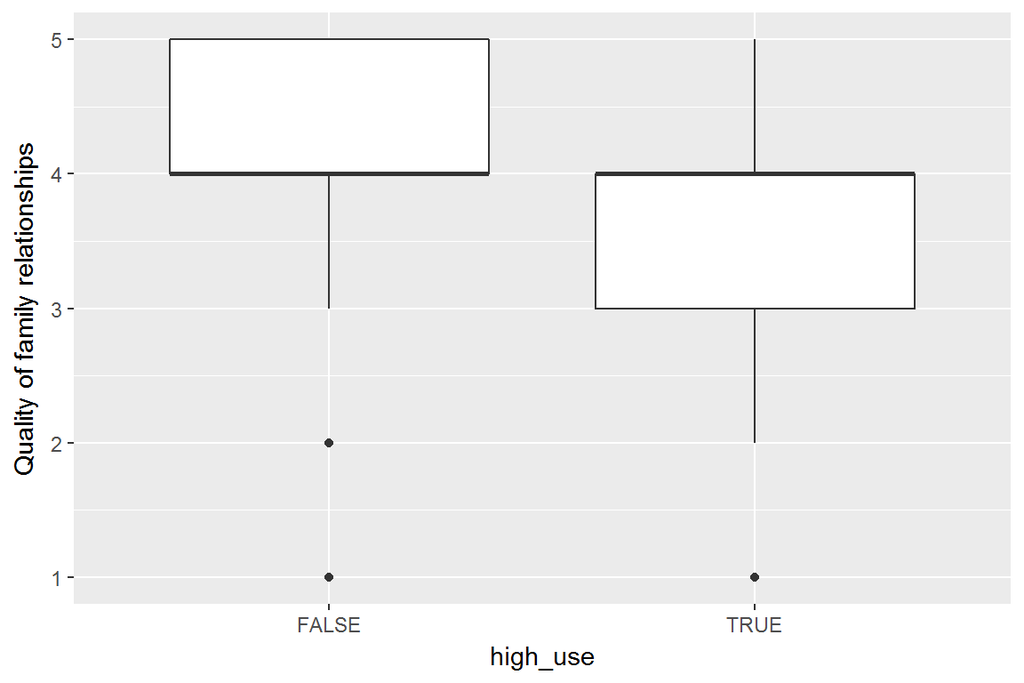

```r
g3 <- ggplot(alc, aes(x = high_use, y = famrel))

# define the plot as a boxplot and draw it
g3 + geom_boxplot() + ylab("Quality of family relationships")
```

As we can see, the box plot is not very ideal for this task: with non-high-users, the 25th percentile and median are the same value, while for the high users the same applies for the median and 75th percentile. This shows as missing halves of the boxes. Still, we can maybe see that the high users have slightly lower scores for the quality of family relationships. Next, let’s look at the romantic relationship variable, and its effect on the alcohol use.

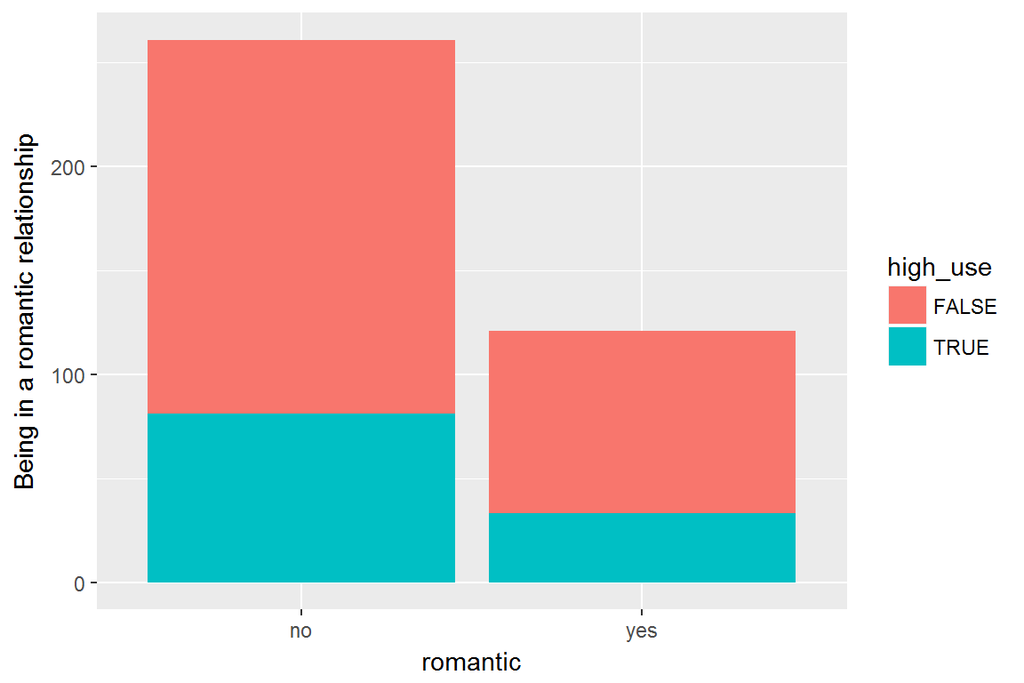

```r
# initialize a plot of alcohol use
g4 <- ggplot(data = alc, aes(x = romantic, fill = high_use))

# define the plot as a bar plot and draw it
g4 + geom_bar() + ylab("Being in a romantic relationship")
```

First of all, we can see that there are around twice as many people not in romantic relationship as those who are. It looks that there might be a bit smaller proportion of high alcohol users in those who are in a romantic relationship, compared to those who are not. We will see this better when we construct the model. As the last of the variables, we will look at the number of school absences. It’s distribution is plotted below:

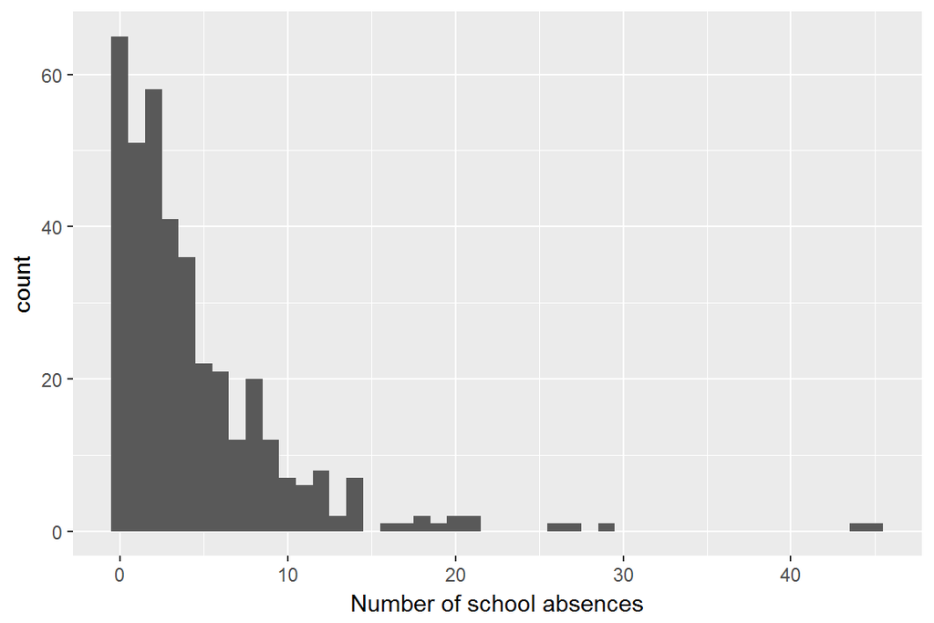

```r
# initialize a plot of alcohol use
g5 <- ggplot(data = alc, aes(x = absences))

# define the plot as a bar plot and draw it
g5 + geom_histogram(binwidth = 1) + xlab("Number of school absences")
```

So most of the people have less than ten absences. Let’s see how high alcohols users compare to others in this respect:

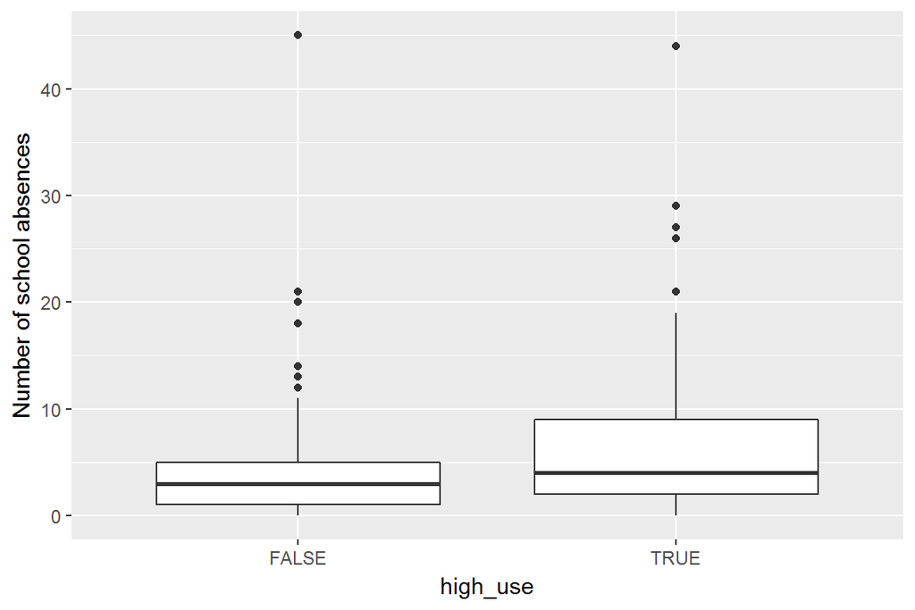

```r
g6 <- ggplot(alc, aes(x = high_use, y = absences))

# define the plot as a boxplot and draw it
g6 + geom_boxplot() + ylab("Number of school absences")
```

Now we can see the box of the high alcohol users extending to clearly more absences. This is in line with the original hypothesis.

Next, let’s fit the binomial model to explore the hypotheses further.

```r
# create the model

# find the model with glm()
m <- glm(high_use ~ famrel + romantic + absences + sex, data = alc, family = "binomial")

# print out a summary of the model
summary(m)
```

```
##
## Call:
## glm(formula = high_use ~ famrel + romantic + absences + sex,
##     family = "binomial", data = alc)
##
## Deviance Residuals:
##     Min       1Q   Median       3Q      Max
## -2.1519  -0.8629  -0.6041   1.0518   2.1051
##
## Coefficients:
##             Estimate Std. Error z value Pr(>|z|)
## (Intercept) -0.59595    0.53889  -1.106   0.2688
## famrel      -0.30086    0.12772  -2.356   0.0185 *
## romanticyes -0.28479    0.26254  -1.085   0.2780
## absences     0.09545    0.02266   4.212 2.53e-05 ***
## sexM         1.01762    0.24399   4.171 3.04e-05 ***
## ---
## Signif. codes:  0 '***' 0.001 '**' 0.01 '*' 0.05 '.' 0.1 ' ' 1
##
## (Dispersion parameter for binomial family taken to be 1)
##
##     Null deviance: 465.68  on 381  degrees of freedom
## Residual deviance: 423.66  on 377  degrees of freedom
## AIC: 433.66
##
## Number of Fisher Scoring iterations: 4
```

Now the high alcohol use is indicated with a true value in the variable. This means that positive coefficients signify increased likelihood of high alcohol usage, while negative coeffcients signify a decreased likelihood. As expected, good familiy relations and romantic relationship decreases the likelihood, while absences and the male sex increase it. Out of the explanatory variables, number of absences and sex are highly significant (p<0.001), and quality of family relationships is still significant (p<0.05). However, the involvment in a romantic relationship is not a statistically significant explanatory variable. So let’s remove that from our model.

```r
# create the model

# find the model with glm()
m <- glm(high_use ~ famrel  + absences + sex, data = alc, family = "binomial")

# print out a summary of the model
summary(m)
```

```
##
## Call:
## glm(formula = high_use ~ famrel + absences + sex, family = "binomial",
##     data = alc)
##
## Deviance Residuals:
##     Min       1Q   Median       3Q      Max
## -2.1998  -0.8427  -0.6062   1.0845   2.1356
##
## Coefficients:
##             Estimate Std. Error z value Pr(>|z|)
## (Intercept) -0.71798    0.52862  -1.358   0.1744
## famrel      -0.29090    0.12744  -2.283   0.0225 *
## absences     0.09351    0.02266   4.127 3.68e-05 ***
## sexM         1.02877    0.24341   4.227 2.37e-05 ***
## ---
## Signif. codes:  0 '***' 0.001 '**' 0.01 '*' 0.05 '.' 0.1 ' ' 1
##
## (Dispersion parameter for binomial family taken to be 1)
##
##     Null deviance: 465.68  on 381  degrees of freedom
## Residual deviance: 424.86  on 378  degrees of freedom
## AIC: 432.86
##
## Number of Fisher Scoring iterations: 4
```

Now all the explanatory variables have a statistically significant relationship with the high alcohol use. To better be able to interpret the coefficients, we will convert them to odds ratios next, and also calculate their confidence intervals:

```r
OR <- exp(coef(m))

# compute confidence intervals (CI)
CI <- exp(confint(m))
# print out the odds ratios with their confidence intervals
cbind(OR, CI)
```

```
##                    OR     2.5 %    97.5 %
## (Intercept) 0.4877368 0.1702903 1.3635949
## famrel      0.7475910 0.5811204 0.9595347
## absences    1.0980228 1.0524564 1.1504519
## sexM        2.7976292 1.7476499 4.5467291
```

The odds ratios describe how much higher the odds for a group are to belong to the high users group, compared to the previous group. So for the sex variable, it tells us that males have over twice as high odds to belong to the high users group compared to females. Similarly, with each unit increase of absences, the odds increase by 10 percent, and with each increase in the family relation quality the odds decreases by 25 percent. Now we neet to also note that the explanatory variables are on different scales: as the sex only takes two values, the difference between these two is big. The absences, on the other hand, have a much wider range of values: even if this affected the alcohol use as much, the difference caused by a unit change in the absences would of course be smaller.

The fact that none of the confidence intervals (CIs) include one confirms that the variables are statistivally significant: if the (95 percent) CI included one, it means that it would be “possible” that a unit increase in the explanatory variable did not change the high alcohol use probability in any direction.

Next, let’s look at how the predictions of the model compare to the real values:

```r
# predict() the probability of high_use
probabilities <- predict(m, type = "response")

# add the predicted probabilities to 'alc'
alc <- mutate(alc, probability = probabilities)

# use the probabilities to make a prediction of high_use
alc <- mutate(alc, prediction = probability > 0.5)

# tabulate the target variable versus the predictions
a = table(high_use = alc$high_use, prediction = alc$prediction)
a
```

```
##         prediction
## high_use FALSE TRUE
##    FALSE   256   12
##    TRUE     85   29
```

Now we classified those individuals, for which the model predicts a probability of 0.5 or more, to be predicted as high users. As we can se from the table, the model classified 256 ($2^{8}$) observations, that are in reality false, to be false. In other words, these were classified correctly. 12 observations that were in reality false were classified as true. Out of the observations that were in reality true, 29 were classified as true, while 85 were classified as false. So out of the observations that really were false, the model correctly classified the majority, while tme majority of the true-in-real-life observations were misclassified. In total, however, the model correctly classified most of the observations, in fact 285 out of the total 382. Thus, the fraction of correctly classified observations is 75 percent. This is better than just random guessing the outcome with 50 percent probablity for each outcome. The fraction of the high users in the data is 30 So if we guessed for every individual that they were not heavy users, we would get 100 - 30 = 70 percent of the cases correct. Our model gives 75 percent. This means that it is better than just best guess without background info on each individual, so it is of some use at least. Even if it had a lower percentage of correctly classified individuals, it could still benefit us in some way. After all, we were now only looking at binary classifications. This means that we discarded most of the information given by the model, in the form of individual probabilities for each subject.

# Chapter 4: Clustering and classification

*Clustering the Boston Suburbs*

We will be attempting to clusted the suburbs of Boston into groups based on housing values in them. The data is part of the MASS package in R, and a more complete description of it can be found [here](https://stat.ethz.ch/R-manual/R-devel/library/MASS/html/Boston.html)

It includes the following variables:

```r
# clear all variables possibly left over from previous sessions
rm(list = ls())

# load libraries

library(GGally)
library(ggplot2)
library(MASS)# access the MASS package
library(dplyr)

# load the data
data("Boston")

# explore the dataset
str(Boston)
```

```
## 'data.frame':    506 obs. of  14 variables:
##  $ crim   : num  0.00632 0.02731 0.02729 0.03237 0.06905 ...
##  $ zn     : num  18 0 0 0 0 0 12.5 12.5 12.5 12.5 ...
##  $ indus  : num  2.31 7.07 7.07 2.18 2.18 2.18 7.87 7.87 7.87 7.87 ...
##  $ chas   : int  0 0 0 0 0 0 0 0 0 0 ...
##  $ nox    : num  0.538 0.469 0.469 0.458 0.458 0.458 0.524 0.524 0.524 0.524 ...
##  $ rm     : num  6.58 6.42 7.18 7 7.15 ...
##  $ age    : num  65.2 78.9 61.1 45.8 54.2 58.7 66.6 96.1 100 85.9 ...
##  $ dis    : num  4.09 4.97 4.97 6.06 6.06 ...
##  $ rad    : int  1 2 2 3 3 3 5 5 5 5 ...
##  $ tax    : num  296 242 242 222 222 222 311 311 311 311 ...
##  $ ptratio: num  15.3 17.8 17.8 18.7 18.7 18.7 15.2 15.2 15.2 15.2 ...
##  $ black  : num  397 397 393 395 397 ...
##  $ lstat  : num  4.98 9.14 4.03 2.94 5.33 ...
##  $ medv   : num  24 21.6 34.7 33.4 36.2 28.7 22.9 27.1 16.5 18.9 ...
```

```r
dim(Boston)
```

```
## [1] 506  14
```

Let’s explore the distributions and relations of the variables:

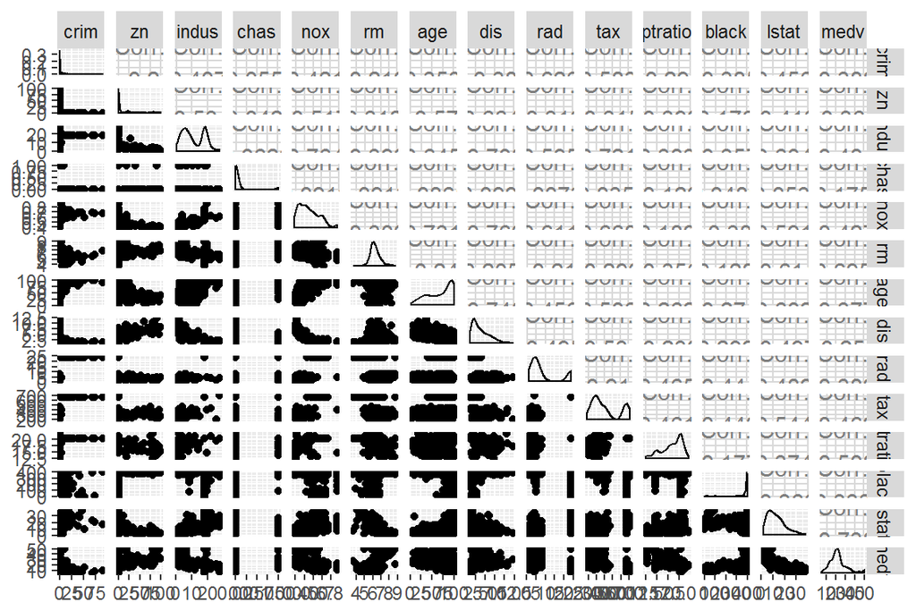

```r
# plot matrix of the variables
p <- ggpairs(Boston, mapping = aes(), lower = list(combo = wrap("facethist", bins = 20)))
p
```

Most of the variables do not seem very normally distributed. In fact, only the variable rm (average number of rooms per dwelling) is anywhere near normal, and even that is slightly skewed. Most of the others have a very wide (NO$_X$, nitrogen oxides in the air), or multimodal (more than one peak: indus, the proportion of non-retail business acres per town) distribution. This could be a problem later on: one of the assumptions of linear discriminant analysis (LDA) that we will be using to classify the suburbs is that the variables used for the classification are normally distributed (within groups). Now we are of course only looking at the total distributions: it would be possible that when looking at the distributions within the groups, the variables would be normally distributed. However, I find this highly unlikely.

The relationships between the variables also seem to vary. Some seem pretty linear, such as the relationship between rm and medv (median value of owner-occupied homes in $1000s.). Some others seem totally non-linear, like NO$_X$ and dis (weighted mean of distances to five Boston employment centres.): here the relationship is a negative one, which makes sense: the farther you are from the centre, the less air pollution you have. Still others are just weird, like age (proportion of owner-occupied units built prior to 1940.) and black (1000(Bk - 0.63)$^2$ where Bk is the proportion of blacks by town.).

Finally, let’s look at some summary statistics of the variables:

```r
library(pastecs) # load pastecs library for easy calculation and presenting of standard deviations
round(stat.desc(Boston),3)[c(1,4,5,8,9,13),] #printing N, min, max, med, mean, sd
```

```
##            crim      zn   indus    chas     nox      rm     age     dis
## nbr.val 506.000 506.000 506.000 506.000 506.000 506.000 506.000 506.000
## min       0.006   0.000   0.460   0.000   0.385   3.561   2.900   1.130
## max      88.976 100.000  27.740   1.000   0.871   8.780 100.000  12.127
## median    0.257   0.000   9.690   0.000   0.538   6.208  77.500   3.207
## mean      3.614  11.364  11.137   0.069   0.555   6.285  68.575   3.795
## std.dev   8.602  23.322   6.860   0.254   0.116   0.703  28.149   2.106
##             rad     tax ptratio   black   lstat    medv
## nbr.val 506.000 506.000 506.000 506.000 506.000 506.000
## min       1.000 187.000  12.600   0.320   1.730   5.000
## max      24.000 711.000  22.000 396.900  37.970  50.000
## median    5.000 330.000  19.050 391.440  11.360  21.200
## mean      9.549 408.237  18.456 356.674  12.653  22.533
## std.dev   8.707 168.537   2.165  91.295   7.141   9.197
```

We can see that both the means and the standard deviations of the variables vary wildly. The standard deviations should be the same for each variable if we want to use them for classification. Only in this way can we assess the similarity of observations using the distances between them. So let’s standardize the variables.

```r
# center and standardize variables
boston_scaled <- as.data.frame(scale(Boston))

round(stat.desc(boston_scaled),3)[c(1,4,5,8,9,13),] #printing N, min, max, med, mean, sd
```

```
##            crim      zn   indus    chas     nox      rm     age     dis
## nbr.val 506.000 506.000 506.000 506.000 506.000 506.000 506.000 506.000
## min      -0.419  -0.487  -1.556  -0.272  -1.464  -3.876  -2.333  -1.266
## max       9.924   3.800   2.420   3.665   2.730   3.552   1.116   3.957
## median   -0.390  -0.487  -0.211  -0.272  -0.144  -0.108   0.317  -0.279
## mean      0.000   0.000   0.000   0.000   0.000   0.000   0.000   0.000
## std.dev   1.000   1.000   1.000   1.000   1.000   1.000   1.000   1.000
##             rad     tax ptratio   black   lstat    medv
## nbr.val 506.000 506.000 506.000 506.000 506.000 506.000
## min      -0.982  -1.313  -2.705  -3.903  -1.530  -1.906
## max       1.660   1.796   1.637   0.441   3.545   2.987
## median   -0.522  -0.464   0.275   0.381  -0.181  -0.145
## mean      0.000   0.000   0.000   0.000   0.000   0.000
## std.dev   1.000   1.000   1.000   1.000   1.000   1.000
```

Now the means are all zero, and the standard deviations one. The non-normality of the variables can be seen, as for some variables the median differs considerably from the mean of zero. Also the minima and maxima of some variables differ a lot. For the rm, which seemed the most normal variable, they are quite close together, and the median is not too far from the mean either.

Next we will classify the suburbs into classes based on the crime rate.

```r
# save the scaled crim as scaled_crim
scaled_crim <- boston_scaled$crim

# create a quantile vector of crim
bins <- quantile(scaled_crim)

# create a categorical variable 'crime'
crime <- cut(scaled_crim, breaks = bins, include.lowest = TRUE, label = c("low", "med_low", "med_high", "high"))

# remove original crim from the dataset
boston_scaled <- dplyr::select(boston_scaled, -crim)

# add the new categorical value to scaled data
boston_scaled <- data.frame(boston_scaled, crime)
```

Now that the classification is done, we will split the data set into a training set (train), which includes 80% of the observations. We’ll choose these “randomly”, but using the same seed for reproducibility.

```r
set.seed(777)

# number of rows in the Boston dataset
n <- nrow(boston_scaled)

# choose randomly 80% of the rows
ind <- sample(n,  size = n * 0.8)

# create train set
train <- boston_scaled[ind,]

# create test set
test <- boston_scaled[-ind,]
```

Having the training and test data done, we are ready to start classifying using LDA. We will try to classify the suburbs into crime rate classes, based on the other data. So, let’s do that next, and plot the results.

```r
# linear discriminant analysis
lda.fit <- lda(crime ~ ., data = train)

# print the lda.fit object
lda.fit
```

```
## Call:
## lda(crime ~ ., data = train)
##
## Prior probabilities of groups:
##       low   med_low  med_high      high
## 0.2623762 0.2425743 0.2450495 0.2500000
##
## Group means:
##                   zn      indus        chas        nox         rm
## low       0.92730082 -0.8767338 -0.08661679 -0.8547381  0.4242730
## med_low  -0.05146847 -0.3489056 -0.03128211 -0.5930089 -0.1193522
## med_high -0.39022525  0.2310140  0.16512651  0.4127645  0.0666368
## high     -0.48724019  1.0171306 -0.03844192  1.0596527 -0.4483671
##                 age        dis        rad        tax    ptratio
## low      -0.8227282  0.8170133 -0.6980048 -0.7555661 -0.4213212
## med_low  -0.3669777  0.4055281 -0.5412349 -0.4869781 -0.0968224
## med_high  0.4252589 -0.3480782 -0.4134380 -0.2909456 -0.2622028
## high      0.7843150 -0.8417034  1.6379981  1.5139626  0.7806252
##                black       lstat        medv
## low       0.37833274 -0.75939334  0.50387326
## med_low   0.35459501 -0.14229320  0.01562712
## med_high  0.06365885  0.02395697  0.14118649
## high     -0.77827648  0.90992464 -0.67672339
##
## Coefficients of linear discriminants:
##                  LD1          LD2         LD3
## zn       0.120963109  0.656131688 -1.07036451
## indus   -0.030280789 -0.299415376  0.10135145
## chas    -0.005662114 -0.027978089  0.05057478
## nox      0.445091047 -0.823125480 -1.20770111
## rm       0.032150810 -0.080017358 -0.15621484
## age      0.274098760 -0.314531013 -0.32791413
## dis     -0.052399339 -0.380304196  0.15239197
## rad      3.083594673  1.011531861 -0.28653303
## tax      0.094370508 -0.088274949  0.84023115
## ptratio  0.164276113 -0.008193075 -0.33669584
## black   -0.132563536  0.045269082  0.15738547
## lstat    0.188199230 -0.178041437  0.56378242
## medv     0.105435628 -0.429509165 -0.04316085
##
## Proportion of trace:
##    LD1    LD2    LD3
## 0.9518 0.0354 0.0128
```

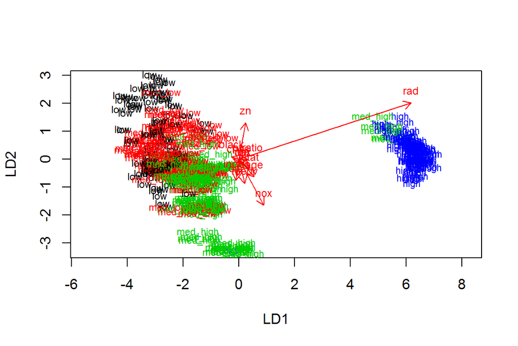

```r
# the function for lda biplot arrows
lda.arrows <- function(x, myscale = 1, arrow_heads = 0.1, color = "red", tex = 0.75, choices = c(1,2)){
  heads <- coef(x)
  arrows(x0 = 0, y0 = 0,
         x1 = myscale * heads[,choices[1]],
         y1 = myscale * heads[,choices[2]], col=color, length = arrow_heads)
  text(myscale * heads[,choices], labels = row.names(heads),
       cex = tex, col=color, pos=3)
}

# target classes as numeric
classes <- as.numeric(train$crime)

# plot the lda results
plot(lda.fit, dimen = 2, col = classes, pch = classes)
lda.arrows(lda.fit, myscale = 2)
```

According to the plot, the suburbs with the high crime rate get very well separated from the others (not regarding the few medium crime rate suburbs that cluster with the high ones). For the other classes the classification is a bit more ambiguous: they are not separated that well on the plot. Next, let’s see how well the model does classifying the test data. For that, we’ll remove the class variable from the test data, and save it separately. That way we can be absolutely sure that the model does not see the actual classes and cheat:)

```r
# save the correct classes from test data
correct_classes <- test$crime

# remove the crime variable from test data
test <- dplyr::select(test, -crime)
```

Now we are ready to classify the test data. Let’s do that, and see the how well the model did.

```r
# predict classes with test data
lda.pred <- predict(lda.fit, newdata = test)

# cross tabulate the results
table(correct = correct_classes, predicted = lda.pred$class)
```

```
##           predicted
## correct    low med_low med_high high
##   low       14       7        0    0
##   med_low    3      19        6    0
##   med_high   1       6       19    1
##   high       0       0        0   26
```

Based on the table, the result seems pretty good! All in all, 78 of the suburbs are correctly classified, while only 24 are not. Again the high crime rate class seems to perform the best: out of the 26 suburbs with high crime rate, 26 were correcrly classified. That is a whopping 100 percent! Also, only 1 observation that did not belong to the “high” group was misclassified in that group. So cool, our LDA worked pretty well.

Now that the LDA is done, let’s move on to k-means clustering. We will first clear all variables from the memory, and reload the Boston data set.

```r
# clear all variables possibly left over from previous sessions
rm(list = ls())

# load the data
data("Boston")

# explore the dataset
str(Boston)
```

```
## 'data.frame':    506 obs. of  14 variables:
##  $ crim   : num  0.00632 0.02731 0.02729 0.03237 0.06905 ...
##  $ zn     : num  18 0 0 0 0 0 12.5 12.5 12.5 12.5 ...
##  $ indus  : num  2.31 7.07 7.07 2.18 2.18 2.18 7.87 7.87 7.87 7.87 ...
##  $ chas   : int  0 0 0 0 0 0 0 0 0 0 ...
##  $ nox    : num  0.538 0.469 0.469 0.458 0.458 0.458 0.524 0.524 0.524 0.524 ...
##  $ rm     : num  6.58 6.42 7.18 7 7.15 ...
##  $ age    : num  65.2 78.9 61.1 45.8 54.2 58.7 66.6 96.1 100 85.9 ...
##  $ dis    : num  4.09 4.97 4.97 6.06 6.06 ...
##  $ rad    : int  1 2 2 3 3 3 5 5 5 5 ...
##  $ tax    : num  296 242 242 222 222 222 311 311 311 311 ...
##  $ ptratio: num  15.3 17.8 17.8 18.7 18.7 18.7 15.2 15.2 15.2 15.2 ...
##  $ black  : num  397 397 393 395 397 ...
##  $ lstat  : num  4.98 9.14 4.03 2.94 5.33 ...
##  $ medv   : num  24 21.6 34.7 33.4 36.2 28.7 22.9 27.1 16.5 18.9 ...
```

```r
dim(Boston)
```

```
## [1] 506  14
```

We already know what’s in the data, so let’s not spend more time looking at that. Instead, let’s again standardize the data to get sensible distance measures for estimating the similarity of observations. Then, let’s calculate the Euclidean distances.

```r
# center and standardize variables
boston_scaled <- as.data.frame(scale(Boston))

# euclidean distance matrix
dist_eu <- dist(boston_scaled)

# look at the summary of the distances
summary(dist_eu)
```

```
##    Min. 1st Qu.  Median    Mean 3rd Qu.    Max.
##  0.1343  3.4620  4.8240  4.9110  6.1860 14.4000
```

Seems that there is at least some variation in the distances: the closest values are only 0.13 units apart, while the farthest are 14 units apart. We’ll try and see if we can cluster the observations using k-means next. To begin with, we’ll request 4 clusters. So next we’ll run the analyses, and plot the results

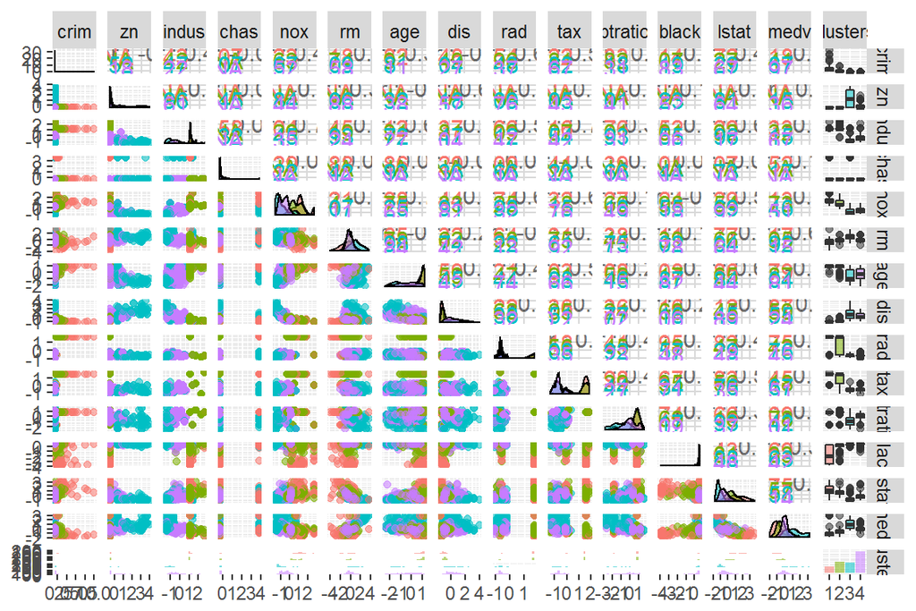

```r
# k-means clustering
km <-kmeans(dist_eu, centers = 4)
boston_scaled$clusters = as.factor(km$cluster)

# plot matrix of the variables
p2 <- ggpairs(boston_scaled, mapping = aes(col = clusters, alpha = 0.3), lower = list(combo = wrap("facethist", bins = 20)))
p2
```

Actually, it now seems that some of the non-normal variables might after all be more normal withing groups. For example the lstat (lower status of the population (percent)), which originally had a very wide and skewed distribution, now seeems to consist of slightly more normal, though still skewed, distributions.

Some of the variables seem to be better at separating the clusters than others. Still all of the variables seem to vary across clusters. For exapmle the aforementioned lstat, and NO$_X$ seem to separate the clusters nicely, as do the tax, medv and indus.

# Chapter 5: Dimension reduction

*Reducing the dimensions of the Human Development data*

We will be attempting to reduce the dimensions in the [Human Development Index (HDI) data](http://hdr.undp.org/en/content/human-development-index-hdidata). The data we are using consists of the HDI data as described in the link, as well as the gender inequality index (GII) data, also described in the link. The data consists of the HDI and GII components by country: the original data also has the components for some regions (such as the whole world), but we have excluded these from the analyses, as well as any countries that have any data missing. This leaves us with 155 observations, and the following variables:

```
## 'data.frame':    155 obs. of  8 variables:
##  $ Edu2.FM  : num  1.007 0.997 0.983 0.989 0.969 ...
##  $ Labo.FM  : num  0.891 0.819 0.825 0.884 0.829 ...
##  $ Life.Exp : num  81.6 82.4 83 80.2 81.6 80.9 80.9 79.1 82 81.8 ...
##  $ Edu.Exp  : num  17.5 20.2 15.8 18.7 17.9 16.5 18.6 16.5 15.9 19.2 ...
##  $ GNI      : int  64992 42261 56431 44025 45435 43919 39568 52947 42155 32689 ...
##  $ Mat.Mor  : int  4 6 6 5 6 7 9 28 11 8 ...
##  $ Ado.Birth: num  7.8 12.1 1.9 5.1 6.2 3.8 8.2 31 14.5 25.3 ...
##  $ Parli.F  : num  39.6 30.5 28.5 38 36.9 36.9 19.9 19.4 28.2 31.4 ...
```

```
## [1] 155   8
```

So there are 155 observations (countries), and 8 variables. The explanations of the variables can be found [here](https://raw.githubusercontent.com/TuomoNieminen/Helsinki-Open-Data-Science/master/datasets/human_meta.txt), thanks to Tuomo Nieminen. For example, the Edu2.FM is the ratio of “Proportion of females with at least secondary education” with “Proportion of males with at least secondary education”. We can call this the evenness of education.

To get a better handle of the data, let’s explore the distributions and relationships of the variables.

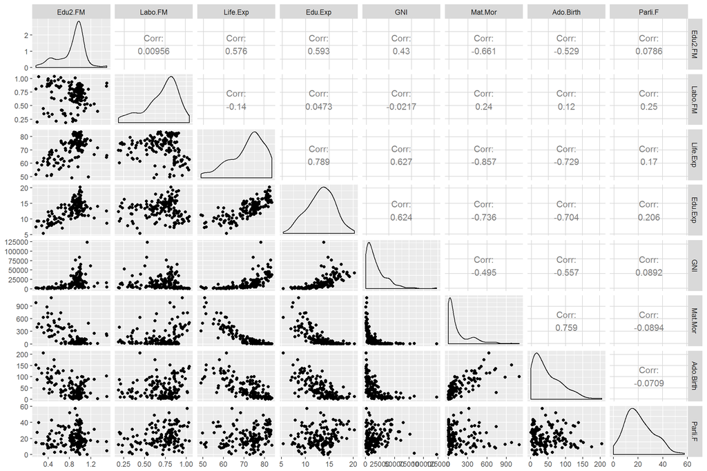

```r
ggpairs(human)
```

Many of the variables seem to have multimodal distributions: that is, they have more than one peak. For example, the ratio of proportion of females having at least secondary education to the males having at least secondary higher education shows a clear peak at around one. This is where roughly as big proportion of females have at least secondary education as males do. However, we can see a lower, but still distinct, peak at around the value 0.5. In these coutries only half as many females have at least secondary education compared to males. The other variables have similar distributions, with the majority of the countries having better and more equal values, and a smaller proportion having clearly worse values. There are some very clear correlations among the variables: for example, the life expectancy and the expected years of schooling show a very clear positive correlation, where as life expectancy and maternal mortality have a negative correlation. Both make total sense. So could it be that both the life expextancy and the expected years of education tell of some underlying phenomenon like general well-being of the country, not directly measured? Hmm…

Let’s still look at the numbers, that is the summary statistics of the individual variables:

```r
summary(human)
```

```
##     Edu2.FM          Labo.FM          Life.Exp        Edu.Exp
##  Min.   :0.1717   Min.   :0.1857   Min.   :49.00   Min.   : 5.40
##  1st Qu.:0.7264   1st Qu.:0.5984   1st Qu.:66.30   1st Qu.:11.25
##  Median :0.9375   Median :0.7535   Median :74.20   Median :13.50
##  Mean   :0.8529   Mean   :0.7074   Mean   :71.65   Mean   :13.18
##  3rd Qu.:0.9968   3rd Qu.:0.8535   3rd Qu.:77.25   3rd Qu.:15.20
##  Max.   :1.4967   Max.   :1.0380   Max.   :83.50   Max.   :20.20
##       GNI            Mat.Mor         Ado.Birth         Parli.F
##  Min.   :   581   Min.   :   1.0   Min.   :  0.60   Min.   : 0.00
##  1st Qu.:  4198   1st Qu.:  11.5   1st Qu.: 12.65   1st Qu.:12.40
##  Median : 12040   Median :  49.0   Median : 33.60   Median :19.30
##  Mean   : 17628   Mean   : 149.1   Mean   : 47.16   Mean   :20.91
##  3rd Qu.: 24512   3rd Qu.: 190.0   3rd Qu.: 71.95   3rd Qu.:27.95
##  Max.   :123124   Max.   :1100.0   Max.   :204.80   Max.   :57.50
```

Now, to try and reduce the dimensions of the data, we will perform principal component analysis (PCA). This method, as far as I know, can reveal some underlying patterns in the data. These could include the general well-being of the country, as discussed earlier.

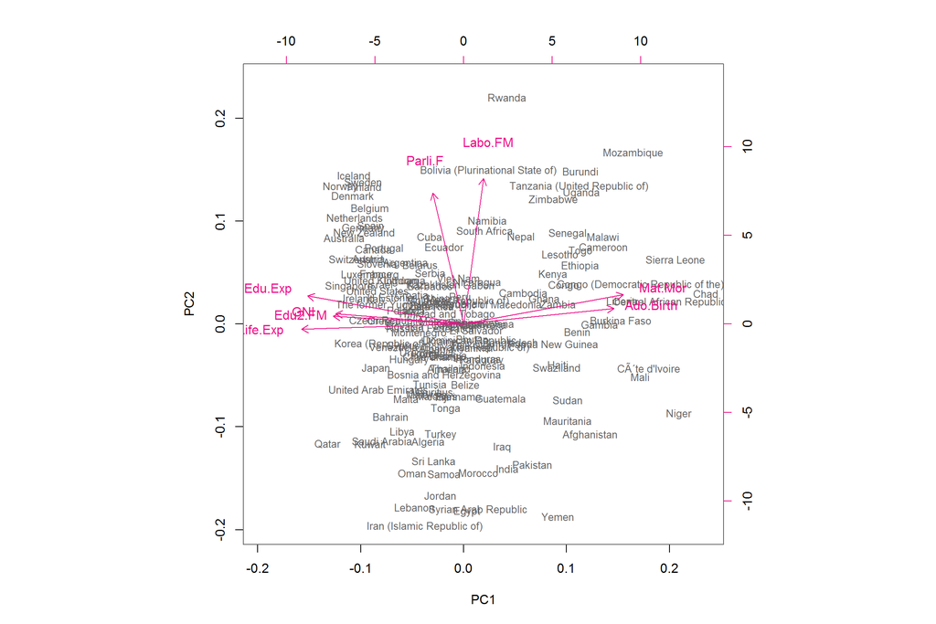

```r
# standardize the variables
human_std <- scale(human)

# perform principal component analysis on the standardized variables (with the SVD method)
pca_human_std <- prcomp(human_std)

# draw a biplot of the principal component representation and the original variables
biplot(pca_human_std, choices = 1:2, cex = c(0.8,1), col = c("grey40","deeppink2"))
```

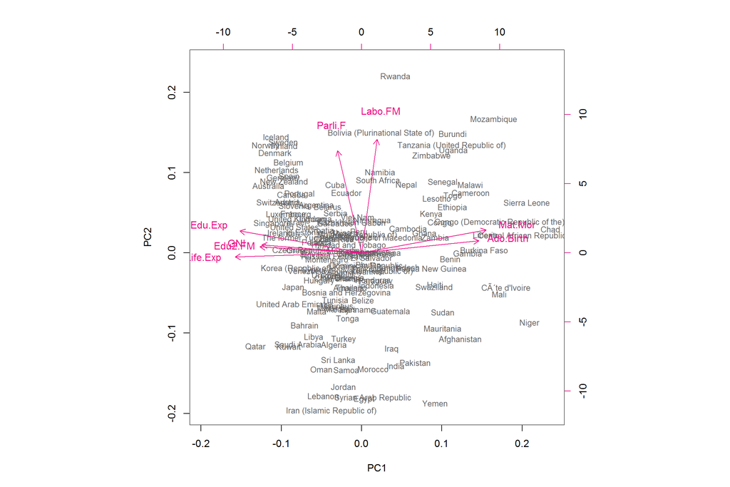

```r
# perform principal component analysis (with the SVD method)
pca_human <- prcomp(human_std)

# draw a biplot of the principal component representation and the original variables
biplot(pca_human, choices = 1:2, cex = c(0.8,1), col = c("grey40","deeppink2"))
```

So it would seem that there is some kind of a disconnect between the general development and life quality of a country, and the equality between the genders. For example, Iran and Qatar seem to have a relatively high “quality of life”, but a low gender equality. In general, Middle Eastern countries seem to have this kind of a relationship between the two. Subsaharan African countries might have high gender equality, but low quality of life in general. This could be caused, among other things, but the high prevalence of HIV in this region (this lowers life expectancy, and is caused by missing birth control, which in turn causes high adolescent birth rate). In the worst quadrant, we have countries such as Afghanistan, Sudan and Niger, where both the quality of life and the gender equality are in a poor shape. These countries have or have generally had some conflict going on: this explains the poor conditions. Thankfully, there are only few countries in this corner of the plot. In the best corner, with high life quality and high equality of genders, we have North and Central Eurpoean countries, especially the Nordic countries. Good for us!

Now that we got started with this super interesting data set about the wellbeing, development and gender equality in the countries all around the world, we’ll stop and move on to explore people’s tea drinking habits. We will start by loading the package FactoMineR, which contains the data set on tea drinking that we are going to use. When we will pick only the columns tea (the type of the the person drinks), (How capital H, how they drink it, f.ex. with lemon), how (little c, how they brew it) sugar (whether they drink it with sugar or not), where (where they get their tea from), and lunch (whether they drink tea with lunch or not, I guess). After that, let’s look at the distributions of the (now categorical) variables:

```r
library(FactoMineR)


data('tea')

# column names to keep in the dataset
keep_columns <- c("Tea", "How", "how", "sugar", "where", "lunch")

# select the 'keep_columns' to create a new dataset
tea_time <- dplyr::select(tea, one_of(keep_columns))

# look at the summaries and structure of the data
summary(tea_time)
```

```
##         Tea         How                      how           sugar
##  black    : 74   alone:195   tea bag           :170   No.sugar:155
##  Earl Grey:193   lemon: 33   tea bag+unpackaged: 94   sugar   :145
##  green    : 33   milk : 63   unpackaged        : 36
##                  other:  9
##                   where           lunch
##  chain store         :192   lunch    : 44
##  chain store+tea shop: 78   Not.lunch:256
##  tea shop            : 30
##
```

```r
str(tea_time)
```

```
## 'data.frame':    300 obs. of  6 variables:
##  $ Tea  : Factor w/ 3 levels "black","Earl Grey",..: 1 1 2 2 2 2 2 1 2 1 ...
##  $ How  : Factor w/ 4 levels "alone","lemon",..: 1 3 1 1 1 1 1 3 3 1 ...
##  $ how  : Factor w/ 3 levels "tea bag","tea bag+unpackaged",..: 1 1 1 1 1 1 1 1 2 2 ...
##  $ sugar: Factor w/ 2 levels "No.sugar","sugar": 2 1 1 2 1 1 1 1 1 1 ...
##  $ where: Factor w/ 3 levels "chain store",..: 1 1 1 1 1 1 1 1 2 2 ...
##  $ lunch: Factor w/ 2 levels "lunch","Not.lunch": 2 2 2 2 2 2 2 2 2 2 ...
```

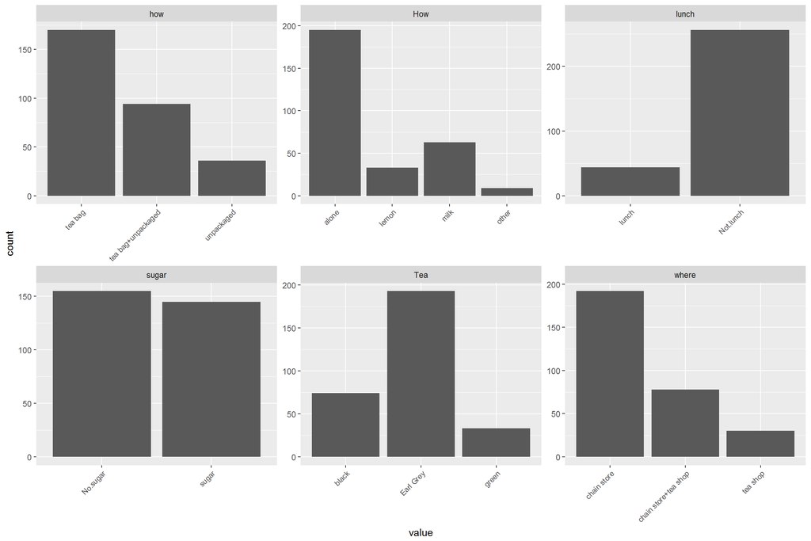

```r
library(tidyr)


# visualize the dataset
gather(tea_time) %>% ggplot(aes(value)) + facet_wrap("key", scales = "free")  + geom_bar() + theme(axis.text.x = element_text(angle = 45, hjust = 1, size = 8))
```

Some variables are more evenly distributed (almost as many people drink their tea with sugar as without), and some are less so (most of the people dirink their tea alone, without any “condiments”). To see which of these categories are related, (f.ex. if the people who use tea bags buy their tea from a chain store), we will perform a multiple correspondence analysis (MCA) on the data.

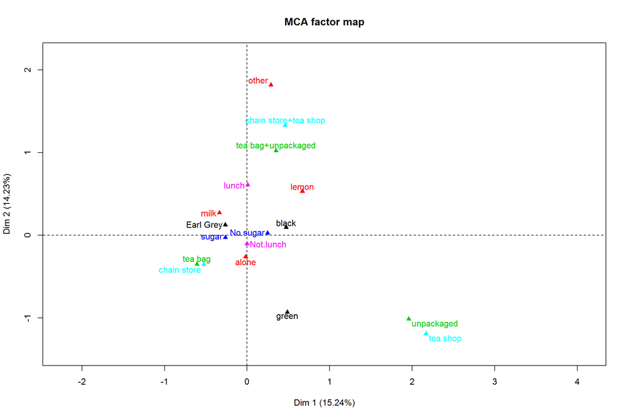

```r
# multiple correspondence analysis
mca <- MCA(tea_time, graph = FALSE)

# summary of the model
#summary(mca)

# visualize MCA
plot(mca, invisible=c("ind"), habillage = "quali")
```

In the plot, the categories that are coloured with the same colour, are categories of the same variable. So all the red points are ways of drinking your tea. The categories close to each other are associated to each other. For example, the unpackaged brewing method and buying your tea from a tea shop, are generally related: so the same people do both. These people are the tea connoisseurs. These two categories are also most separate from others. The other forms form more of a continuum, with less clear diferences between neighbouring classes.